# Week1

```python
import seaborn as sns
import pandas as pd
import numpy as np
```

## Assignment 3

15 min: Perform a univariate analysis on all the categorical data of the penguins dataset. Commit the notebook to your portfolio when you're finished.

```python
penguins = sns.load_dataset("penguins")
```

```python
penguins.head()
```

|  | species | island | bill_length_mm | bill_depth_mm | flipper_length_mm | body_mass_g | sex |
| --- | --- | --- | --- | --- | --- | --- | --- |
| 0 | Adelie | Torgersen | 39.1 | 18.7 | 181.0 | 3750.0 | Male |
| 1 | Adelie | Torgersen | 39.5 | 17.4 | 186.0 | 3800.0 | Female |
| 2 | Adelie | Torgersen | 40.3 | 18.0 | 195.0 | 3250.0 | Female |
| 3 | Adelie | Torgersen | NaN | NaN | NaN | NaN | NaN |
| 4 | Adelie | Torgersen | 36.7 | 19.3 | 193.0 | 3450.0 | Female |

### Species

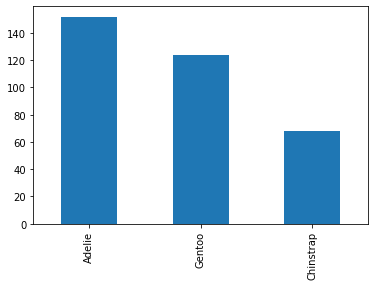

```python
penguins['species'].value_counts().plot(kind='bar')
```

## Islands

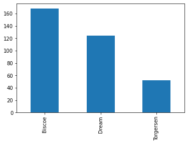

```python
penguins['island'].value_counts().plot(kind='bar')
```

### Sex

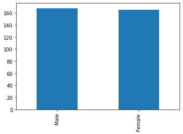

```python
penguins['sex'].value_counts().plot(kind='bar')
```

## Assignment 4

15 min: Look online for a datset that you personally find interesting to explore. It can be about any topic that you find interesting: sports, games, software development, etc. Commit the dataset to your portfolio. You will be analysing the dataset in future portfolio assignments.

Required characteristics of the dataset:

Must be in a tabular format: Contains rows and columns Contains at least 100 rows Contains at least 2 columns with categorical data and at least 2 columns with numerical data Is less than 200 MB

```python
LecDataset = pd.read_csv('Datasets/lec_playerdata.csv', sep=',')
LecDataset.head()
```

|  | Unnamed: 0 | Player | Team | Pos | GP | W% | K | D | A | KDA | ... | CSD10 | CSPM | CS%P15 | DPM | DMG% | EGPM | Gold% | WPM | WCPM | Split |
| --- | --- | --- | --- | --- | --- | --- | --- | --- | --- | --- | --- | --- | --- | --- | --- | --- | --- | --- | --- | --- | --- |
| 0 | 0 | Abbedagge | Schalke 04 | Middle | 19.0 | 47.0 | 41.0 | 43.0 | 79.0 | 2.8 | ... | -3.3 | 9.0 | 26.6 | 417.0 | 24.6 | 257.9 | 22.5 | 0.51 | 0.19 | Spring Regular |
| 1 | 1 | Alphari | Origen | Top | 18.0 | 67.0 | 29.0 | 30.0 | 73.0 | 3.4 | ... | 1.7 | 8.0 | 22.4 | 354.0 | 21.8 | 243.5 | 20.9 | 0.54 | 0.15 | Spring Regular |
| 2 | 2 | Attila | Vitality | ADC | 18.0 | 56.0 | 48.0 | 30.0 | 77.0 | 4.2 | ... | -3.9 | 10.2 | 33.4 | 458.0 | 25.6 | 316.7 | 26.9 | 0.35 | 0.39 | Spring Regular |
| 3 | 3 | Broxah | Fnatic | Jungle | 18.0 | 61.0 | 49.0 | 27.0 | 93.0 | 5.3 | ... | -1.8 | 5.0 | 13.2 | 255.0 | 14.9 | 200.1 | 17.1 | 0.36 | 0.34 | Spring Regular |
| 4 | 4 | Bwipo | Fnatic | Top | 18.0 | 61.0 | 41.0 | 42.0 | 80.0 | 2.9 | ... | -10.0 | 7.6 | 23.6 | 444.0 | 25.5 | 239.7 | 20.4 | 0.48 | 0.16 | Spring Regular |

5 rows × 25 columns

### Portfolio assignment 5

20 min:

- Download lifeExpectancyAtBirth.csv from Onderwijsmateriaal/Datasets on Blackboard.
- Move the file to the same folder as the Notebook that you will be working in.
- Load the dataset in your Notebook with the following code: lifeExpectancy = pd.read_csv('Datasets/lifeExpectancyAtBirth.csv', sep=',')
- Look at the dataset with the .head() function.
- Filter the dataframe: We only want the life expectancy data about 2019 and 'Both sexes'
- Use this dataframe to perform a univariate analysis on the life expectancy in 2019.

Commit the notebook and dataset to your portfolio when you're finished.

```python
lifeExpectancy = pd.read_csv('Datasets/lifeExpectancyAtBirth.csv', sep=',')
lifeExpectancy.head()
```

|  | Location | Period | Indicator | Dim1 | First Tooltip |
| --- | --- | --- | --- | --- | --- |
| 0 | Afghanistan | 2019 | Life expectancy at birth (years) | Both sexes | 63.21 |
| 1 | Afghanistan | 2019 | Life expectancy at birth (years) | Male | 63.29 |
| 2 | Afghanistan | 2019 | Life expectancy at birth (years) | Female | 63.16 |
| 3 | Afghanistan | 2015 | Life expectancy at birth (years) | Both sexes | 61.65 |
| 4 | Afghanistan | 2015 | Life expectancy at birth (years) | Male | 61.04 |

```python
filteredLifeExpectancy = lifeExpectancy[(lifeExpectancy['Dim1'] == 'Both sexes') & (lifeExpectancy['Period'] == 2019)]
filteredLifeExpectancy.head()
```

|  | Location | Period | Indicator | Dim1 | First Tooltip |
| --- | --- | --- | --- | --- | --- |
| 0 | Afghanistan | 2019 | Life expectancy at birth (years) | Both sexes | 63.21 |
| 12 | Albania | 2019 | Life expectancy at birth (years) | Both sexes | 78.00 |
| 24 | Algeria | 2019 | Life expectancy at birth (years) | Both sexes | 77.13 |
| 36 | Angola | 2019 | Life expectancy at birth (years) | Both sexes | 63.06 |
| 48 | Antigua and Barbuda | 2019 | Life expectancy at birth (years) | Both sexes | 76.45 |

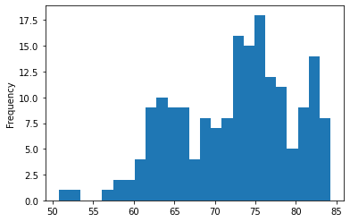

```python
analysisYear = filteredLifeExpectancy['First Tooltip']
analysisYear.plot(kind='hist', bins=25)
```

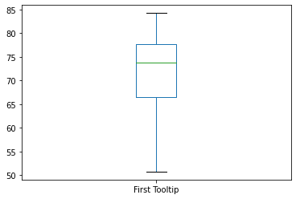

```python
analysisYear.plot(kind='box')
```

##### Mean (Gemiddelde)

```python
analysisYear.mean()
```

```
72.54049180327873
```

##### Median (Middelste nummer)

```python
analysisYear.median()
```

```
73.74
```

##### Std (Afwijking)

```python
analysisYear.std()
```

```
7.129956404370866
```

##### Max and Min

```python
analysisYear.max()
```

```
84.26
```

```python
analysisYear.min()
```

```
50.75
```

### Portfolio assignment 6

60 min: Perform a univariate analysis on at least 2 columns with categorical data and on at least 2 columns with numerical data in the dataset that you chose in portfolio assignment 4. Commit the Notebook to your portfolio when you're finished.

#### Categorical data Teams

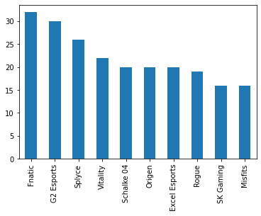

```python
LecDataset['Team'].value_counts().plot(kind='bar')
```

#### Categorical data Positions

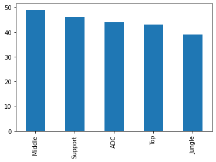

```python
LecDataset['Pos'].value_counts().plot(kind='bar')
```

#### Numerical data GP

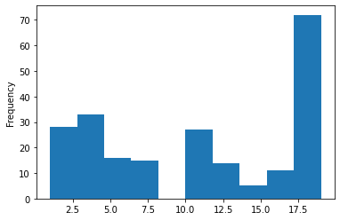

```python
LecGP = LecDataset['GP']
LecGP.plot(kind='hist', bins=10)
```

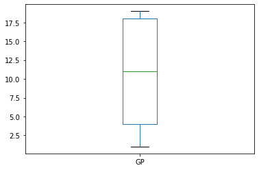

```python
LecGP.plot(kind='box')
```

##### Mean (Gemiddelde)

```python
LecGP.mean()
```

```
10.76923076923077
```

##### Median (Middelste nummer)

```python
LecGP.median()
```

```
11.0
```

##### Std (Afwijking)

```python
LecGP.std()
```

```
6.587602257005468
```

##### Max and Min

```python
LecGP.max()
```

```
19.0
```

```python
LecGP.min()
```

```
1.0
```

#### Numerical data K

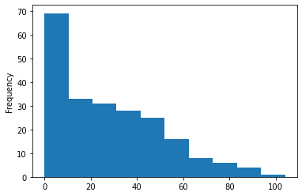

```python
LecK = LecDataset['K']
LecK.plot(kind='hist', bins=10)
```

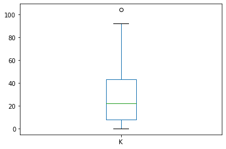

```python
LecK.plot(kind='box')
```

##### Mean (Gemiddelde)

```python
LecK.mean()
```

```
27.90950226244344
```

##### Median (Middelste nummer)

```python
LecK.median()
```

```
22.0
```

##### Std (Afwijking)

```python
LecK.std()
```

```
22.98796029202014
```

##### Max and Min

```python
LecK.max()
```

```
104.0
```

```python
LecK.min()
```

```
0.0
```

### Portfolio assignment 7

15 min: Look at the histogram of at least 2 columns with numerical data in the dataset that you chose in portfolio assignment 4. Do you recognise the distribution? Does it look like a uniform or normal distribution or something else? If it doesn't look like a uniform or normal distribution, take a quick look here to see if you can find the distribution shape: https://www.itl.nist.gov/div898/handbook/eda/section3/eda366.htm

#### Numerical data GP

```python
averageGP = LecGP.mean()
stdGP = LecGP.std()
numberOfPlayersSample = 10000
```

```python
randomGP = pd.Series( np.random.normal(averageGP, stdGP, numberOfPlayersSample) )
```

```python
randomGP.head()
```

```
0    16.744586
1    12.356254
2    10.697867
3    16.829096
4    12.105370
dtype: float64
```

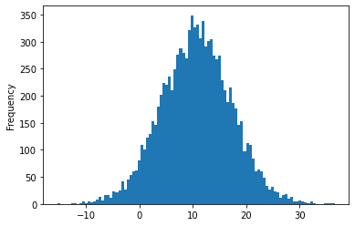

```python
randomGP.plot(kind='hist', bins=100)
```

#### Numerical data K

```python
averageK = LecK.mean()
stdK = LecK.std()
```

```python
randomK = pd.Series( np.random.normal(averageK, stdK, numberOfPlayersSample) )
```

```python
randomK.head()
```

```
0     3.272287
1    54.891540
2    24.512689
3    27.334531
4    57.223269
dtype: float64
```

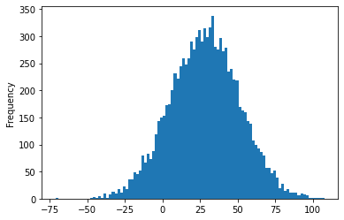

```python
randomK.plot(kind='hist', bins=100)
```

### Portfolio assignment 8

15 min:

- Calculate the 90%, 95%, 99% and 99.99% confidence interval for at least 2 columns with numerical data in the dataset that you chose in portfolio assignment 4. Do you see the impact the confidence has on the interval?
- Now calculate the 95% confidence interval again but use only the first 10% of your rows. Compare this interval to the previous 95% confidence interval you calculated. Do you see the impact of having less data?

```python
import scipy.stats as st
confidenceOne = 0.90
confidenceTwo = 0.95
confidenceThree = 0.99
confidenceFour = 0.9999
LengthLec = len(LecDataset)-1
LengthLecTen = LengthLec*0.10
LecGPTenProcent = LecDataset.head(10)
```

#### Numerical data GP

90% Confidence

```python
st.t.interval(confidenceOne, LengthLec, loc=averageGP, scale=st.sem(LecGP) )
```

```
(10.037264385594126, 11.501197152867412)
```

95% Confidence

```python
st.t.interval(confidenceTwo, LengthLec, loc=averageGP, scale=st.sem(LecGP) )
```

```
(9.895907526268761, 11.642554012192779)
```

99% Confidence

```python
st.t.interval(confidenceThree, LengthLec, loc=averageGP, scale=st.sem(LecGP) )
```

```
(9.617818878635072, 11.920642659826468)
```

99.99% Confidence

```python
st.t.interval(confidenceFour, LengthLec, loc=averageGP, scale=st.sem(LecGP) )
```

```
(9.013056063758418, 12.525405474703122)
```

Length 10% - 95% Confidence

```python
st.t.interval(confidenceTwo, LengthLec*0.10, loc=LecGP[0:int(LengthLecTen)].mean(), scale=st.sem(LecGP[0:int(LengthLecTen)]) )
```

```
(15.70817218934586, 18.655464174290508)
```

#### Numerical data K

90% Confidence

```python
st.t.interval(confidenceOne, LengthLec, loc=averageK, scale=st.sem(LecK) )
```

```
(25.355247541882708, 30.46375698300417)
```

95% Confidence

```python
st.t.interval(confidenceTwo, LengthLec, loc=averageK, scale=st.sem(LecK) )
```

```
(24.86197157554449, 30.957032949342388)
```

99% Confidence

```python
st.t.interval(confidenceThree, LengthLec, loc=averageK, scale=st.sem(LecK) )
```

```
(23.89155919482332, 31.92744533006356)
```

99.99% Confidence

```python
st.t.interval(confidenceFour, LengthLec, loc=averageK, scale=st.sem(LecK) )
```

```
(21.781191411205125, 34.03781311368176)
```

Length 10% - 95% Confidence

```python
st.t.interval(confidenceTwo, LengthLec*0.10,  loc=LecK[0:int(LengthLecTen)].mean(), scale=st.sem(LecK[0:int(LengthLecTen)]) )
```

```
(29.249312815077655, 49.841596275831435)
```